# Case Study 04

Andrew Benson

February 3, 2018

## Summary of “Effectively Communicating Numbers”

The most important thing in this article is probably the idea that distractions need to be removed from graphs. If it doesn’t contribute to the message that you are trying to convey, then there is not reason to have it. There is also an art behind building graphics. Data scientists need to think about where to put tick marks, when to include tables and what type of graphic to use. A keen eye for these small details can go a long ways.

## Five Thirty Eight Article

The Five Thirty Eight article combines data analysis with a new story that shows different statistics about gun deaths. The data comes from multiple sources but is compiled into one data set. The aim of the article is to demonstrate that there is not one solution to fixing the problems around gun deaths as there are many different causes.

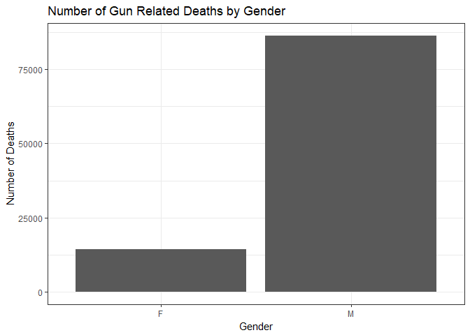

```r
guns %>%
  ggplot() +
  geom_bar(aes(x = sex)) +
  theme_bw() +
  labs(x = "Gender", y = "Number of Deaths", title = "Number of Gun Related Deaths by Gender")
```

In the first graphic shown below portrays the number of deaths for each time of the season. This main message is that suicide is by far the largest factor for loss of life through guns. The other message is that suicide, as well as homicide is lower in the winter.

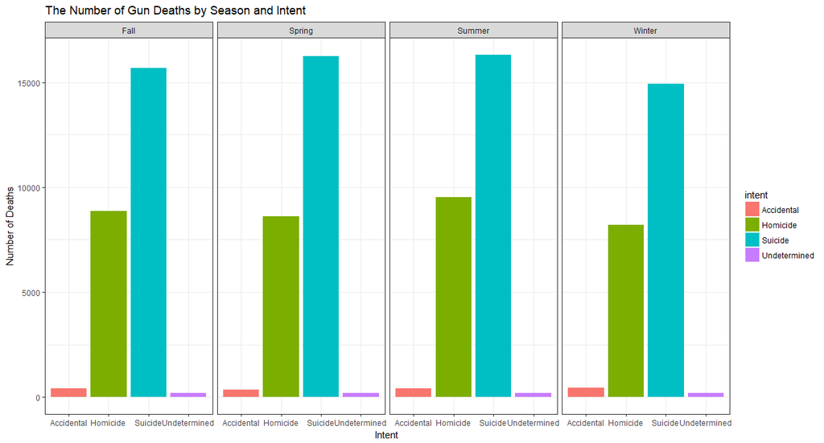

```r
s.guns <- guns %>%
  mutate(
    season = case_when(
      month == "03" ~ "Spring",
      month == '04' ~ "Spring",
      month == '05' ~ "Spring",
      month == '06' ~ "Summer",
      month == '07' ~ "Summer",
      month == '08' ~ "Summer",
      month == '09' ~ "Fall",
      month == '10' ~ "Fall",
      month == '11' ~ "Fall",
      month == '12' ~ "Winter",
      month == '01' ~ "Winter",
      month == '02' ~ "Winter",
      TRUE ~ "other"
    )
  )

s.guns %>%
  filter(intent != is.na(intent)) %>%
  ggplot(aes(x = intent, fill = intent)) +
  geom_bar() +
  facet_grid(~season) +
  theme_bw() +
  labs(x = "Intent", y = "Number of Deaths", title = "The Number of Gun Deaths by Season and Intent")
```

In this second graphic, shows the trend in the data for each type of intent. Homicide seems to be going down while suicide going up. For the other graphics it is difficult to tell. If given more time it would have been better to splint out all graphics into their own graphic.

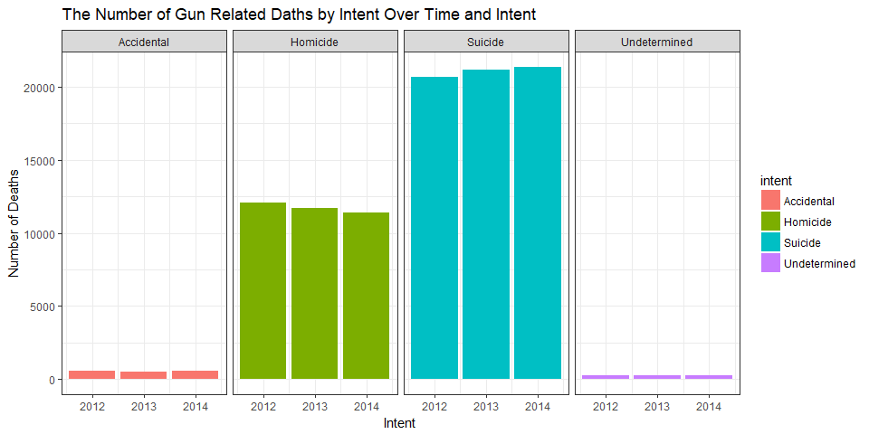

```r
s.guns %>%
  filter(intent != is.na(intent)) %>%
  ggplot(aes(x = year, fill = intent)) +
  geom_bar() +
  facet_grid(~intent) +
  theme_bw() +
  labs(x = "Intent", y = "Number of Deaths", title = "The Number of Gun Related Daths by Intent Over Time and Intent")
```